# riskRegression: Predicting the Risk of an Event using Cox Regression Models

# Predicting absolute risks based on cause-specific Cox regression

We denote by $T$ the time between a baseline date and the date of an event and by $D\in\{1,...,K\}$ the cause of the event. We assume that $\{D=1\}$ is the event of interest. Let $X=(X^{1}, \dots,X^{p})$ be a $p$-dimensional vector of baseline covariates with arbitrary distribution, and $Z=(Z^1,\dots,Z^{q})$ be the strata variables, i.e. a set of categorical baseline covariates with finitely many possible values. Without loss of generality and to ease the notation we set $q=1$. We use $\{1,\dots,L\}$ for the categories of $Z$.

We consider a setting in which the event time $T$ is right censored at a random time $C$. We assume that $C$ is conditionally independent of $T$ given $(X,Z)$ and fix a time $\tau$ such that almost surely $\mathrm P(C>\tau|X,Z)>0$. We denote $\tilde T=\min(T,C)$, $\tilde D = \Delta D$, and $\Delta=1\{T\le C\}$.

## Cause-specific Cox regression

Given covariates $(X,Z)$, let $S_0(t|x,z)=P(T>t|X=x,Z=z)$ denote the event-free survival function and $F_j(t|x,z)=P(T\le t, D=j|X=x,Z=z)$ the cumulative incidence function for event $j$. The cause-specific hazard rates are defined as $\lambda_{j,z}(t|x)=\mathrm d F_j(t|x,z)/S_0(t|x,z)$ (Andersen et al. 1993). We also denote the cumulative hazard rates by $\Lambda_{j,z}(t|x)=\int_0^t\lambda_{j,z}(s|x)\mathrm d s$. The stratified Cox regression model (Cox 1972) for cause $j$ is given by
$$\label{sHazard}
\lambda_{j,z}(t|x)=
\lambda_{0j,z}(t)\exp(x\beta_j), (\#eq:sHazard)$$
where $\beta_j={(\beta_j^1,\dots,\beta_j^p)}^\intercal$ is a $p$-dimensional vector of regression coefficients (the log-hazard ratios), and $\{\lambda_{0j,z}(t): z=1,\dots,L\}$ a set of unspecified baseline hazard functions.

## Predicting the absolute risk of an event

The cause-specific Cox regression models can be combined into a prediction of the absolute risk of an event of type $1$ until time $t$ conditional on the covariates $x,z$. For the case where $K=2$ the absolute risk formula of (Benichou and Gail 1990) is given by:
$$\label{absRisk}
F_1 (t|x,z)=\int_0^t S(s-|x,z)\lambda_{1,z}(s|x) \mathrm
ds. (\#eq:absRisk)$$
where $s-$ denotes the right sided limit, e.g. $\Lambda_{1,z}(s-|x)=lim_{v \rightarrow s, v<s}\Lambda_{1,z}(v|x)$. The absolute risk accumulates over time the product between the event-free survival and the hazard of experiencing the event of interest, both conditional to the baseline covariates and to the strata variable. The event free survival can be estimated from the cause-specific hazards using the product integral estimator:

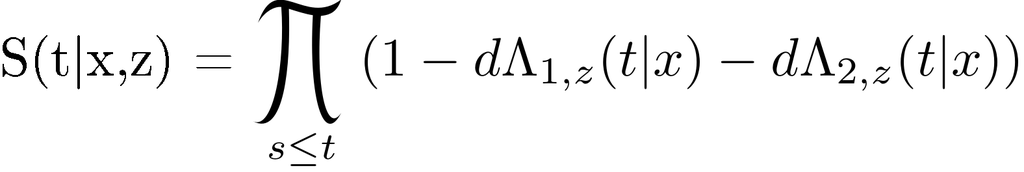

or the exponential approximation:
$$\label{survivalEXP}
\widehat{S}(t|x,z)=\exp \bigg[ - \widehat{\Lambda}_{1,z}(t|x) -
\widehat{\Lambda}_{2,z}(t|x)\bigg]. (\#eq:survivalEXP)$$
which is asymptotically equivalent to the product-limit estimator if the distribution of the event times is continuous. Using the product integral estimator ensures that $S(t|x,z)+F_1(t|x,z)+F_2(t|x,z)$ equals exactly $1$. This is a desirable property since the sum of the transition probabilities over all possible transitions should sum to one.

Formula @ref(eq:absRisk) generalizes to situations with more than 2 competing risks, i.e., $K>2$. However, in applications with many competing risks there will sometimes be few events of specific causes, and it may be hard to fit a Cox regression model for each cause separately. One possibility when $K>2$ is to combine all causes where $\tilde D>1$ into a single competing risk for the cause of interest $\tilde D=1$. While the *riskRegression* package allows the use of more than 2 competing risks, we will illustrate its use considering only 2 competing risks . The package implements formula @ref(eq:absRisk) in two steps.

### Step 1: estimation of the cause-specific hazards

The first step is to fit the Cox regression models with the `CSC()` function in order to estimate $\lambda_{1,z}$ and $\lambda_{2,z}$:

```r
cfit0 <- CSC(formula = Hist(time,status) ~ age + logthick + epicel + strata(sex),
         data = Melanoma)
coef(cfit0)
```

```r
## $`Cause 1`
##           age      logthick epicelpresent
##    0.01548722    0.68178505   -0.73848649
##
## $`Cause 2`
##           age      logthick epicelpresent
##    0.07680909    0.04750975    0.31497177
```

In the call of `CSC()` the argument `formula` is used to define the outcome variables with the help of the function `prodlim::Hist()`. The variable “time” in the data set contains the values of the observed event time $\tilde T$ and the variable “status” the cause of the event $\tilde D$. Objects generated with the function `prodlim::Hist()` have a print method:

```r
h <- with(Melanoma, prodlim::Hist(time,status))
h
```

```r
## Right-censored response of a competing.risks model
##
## No.Observations: 205
##
## Pattern:
##
## Cause     event right.censored
##   1          57              0
##   2          14              0
##   unknown     0            134
```

and a plot method:

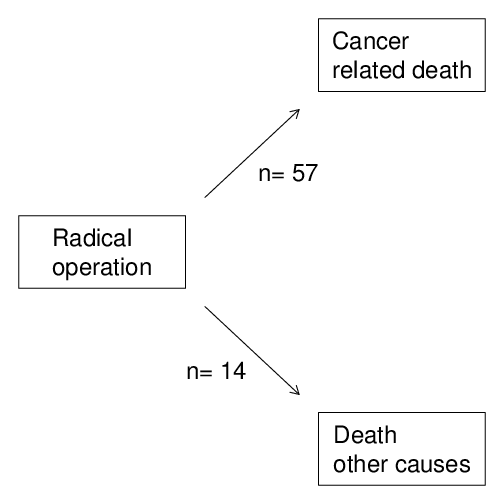

Figure 1: Box-arrow diagram showing the three states of the competing risk model and the number of observed transitions in the *Melanoma* data set.

```r
plot(h, arrowLabelStyle = "count",
     stateLabels = c("Radical\noperation", "Cancer\nrelated death", "Death\nother causes"))
```

A nice complement to the regression models is the marginal Aalen-Johansen estimate of the absolute risk of cancer related death (2):

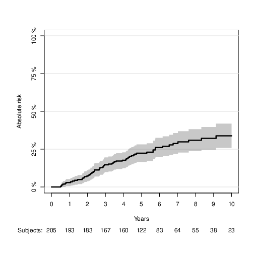

Figure 2: Non-parametric estimation of the absolute risk of cancer related death over time obtained using the Aalen-Johansen estimator.

```r
library(prodlim)
plot(prodlim(Hist(time,status)  ~1, data = Melanoma),
     atrisk.at = seq(0,3652.5,365.25), xlim = c(0,3652.5),
     axis1.at = seq(0,3652.5,365.25), axis1.lab = 0:10,
     xlab = "Years", ylab = "Absolute risk", cause = 1)
```

The right hand side of the formula in the call of the `CSC()` function:

```r
Hist(time,status) ~ age + logthick + epicel + strata(sex)
```

defines the covariate(s) $X$ which enter into the linear predictor $x\beta$ in formula @ref(eq:sHazard), and the strata variable(s) $Z$ which define the baseline hazard functions $\lambda_{0j,z}$. Strata variables are specified by wrapping the variable names into the special function `strata()`, as one would do when using the `coxph()` function. If only one formula is provided, the `CSC()` function will use the same baseline covariates and strata variables for all cause-specific Cox regression models. Instead one may feed a list of formulas into the argument `formula`, one for each cause:

```r
cfit1 <- CSC(formula = list(Hist(time,status) ~ age + logthick + epicel + strata(sex),
                Hist(time,status) ~ age + strata(sex)),
         data = Melanoma)
coef(cfit1)
```

```r
## $`Cause 1`
##           age      logthick epicelpresent
##    0.01548722    0.68178505   -0.73848649
##
## $`Cause 2`
##        age
## 0.07919648
```

Note that the choice of the baseline covariates relative to each cause made here is not based on clinical or statistical criteria; it was done to illustrate the software possibilities. The causes are internally ordered with respect to the levels of the variable “status”, if this variable is a factor, and otherwise with respect to `sort(as.character(unique(status)))`. The order of the causes is saved as `cfit1[["causes"]]`. Accordingly, the first formula is used to fit a Cox regression model to the first cause and the second formula is used to fit a Cox regression model to the second cause and so on. Internally, `CSC()` constructs dummy variables, one for each cause, and then calls the function defined by the argument `fitter` on a suitably constructed `Surv()` formula. By default the cause-specific Cox models are fitted with the function `survival::coxph()`. Alternatively, one can set the argument `fitter` to the name of a different routine, e.g., `cph`.

### Step 2: computation of the absolute risk

The object obtained with `CSC()` has class `"CauseSpecificCox"`. The second step is to call the corresponding `predict()` method. In addition to the object obtained with `CSC()` this requires three additional arguments: `newdata`, `times`, `cause`. The argument `newdata` should be a `"data.frame"` which contains the covariates $X$ and $Z$ in the same format as the data used to fit `CSC()`. The argument `cause` defines the cause of interest $D$ and the argument `times` defines a vector of prediction horizon(s) whose values are used as the upper integration limit $t$ in formula @ref(eq:absRisk). The `predict()` method computes the absolute risks (formula @ref(eq:absRisk)) for each row in `newdata` and each value of `times`:

```r
newdata <- data.frame(age = c(45,67), logthick = c(0.1,0.2),
                      epicel = c("present","not present"),
                      sex = c("Female","Male"))
pfit1 <- predict(cfit1, newdata = newdata, cause = 1, times = c(867,3500))
```

By default, the product integral estimator is used to estimate the event-free survival function. Setting the argument `productLimit` to `FALSE` when calling the predict function enables to use the exponential approximation. The predict function returns a structured list of class `"predictCSC"`. The corresponding `print()` method calls `as.data.table.predictCSC()` to display the predictions as follows:

```r
print(pfit1)
```

```r
##    observation age logthick      epicel    sex times     strata absRisk
## 1:           1  45      0.1     present Female   867 sex=Female   0.021
## 2:           2  67      0.2 not present   Male   867   sex=Male   0.149
## 3:           1  45      0.1     present Female  3500 sex=Female   0.117
## 4:           2  67      0.2 not present   Male  3500   sex=Male   0.428
```

For each row in `newdata` (values are repeated for each prediction horizon) and each prediction horizon (column `times`) the column “absRisk” contains the absolute risk of cancer specific mortality (cause 1). Standard errors and confidence intervals for the absolute risk can be obtained setting the argument `se` to `TRUE`:

```r
pfit1se <- predict(cfit1, newdata = newdata, cause = 1, times = c(867,3500),
           se = TRUE, keep.newdata = FALSE)
print(pfit1se)
```

```r
##    observation times     strata absRisk absRisk.se absRisk.lower absRisk.upper
## 1:           1   867 sex=Female   0.021      0.122       0.00738        0.0478
## 2:           2   867   sex=Male   0.149      0.161       0.07356        0.2502
## 3:           1  3500 sex=Female   0.117      0.151       0.05552        0.2025
## 4:           2  3500   sex=Male   0.428      0.320       0.20416        0.6355
```

Here we have set the argument `keep.newdata` to `FALSE` to not export the value of the covariates. The structure of the `"predictCSC"` object is as follows.

```r
str(pfit1se)
```

```r
## List of 11
##  $ absRisk               : num [1:2, 1:2] 0.021 0.149 0.117 0.428
##  $ absRisk.se            : num [1:2, 1:2] 0.122 0.161 0.151 0.32
##  $ absRisk.lower         : num [1:2, 1:2] 0.00738 0.07356 0.05552 0.20416
##  $ absRisk.upper         : num [1:2, 1:2] 0.0478 0.2502 0.2025 0.6355
##  $ times                 : num [1:2] 867 3500
##  $ strata                : Factor w/ 2 levels "sex=Female","sex=Male": 1 2
##  $ conf.level            : num 0.95
##  $ se                    : logi TRUE
##  $ band                  : logi FALSE
##  $ nsim.band             : num 10000
##  $ transformation.absRisk:function (x)
##  - attr(*, "class")= chr "predictCSC"
```

The elements `$absRisk`, `$absRisk.se`, `$absRisk.lower` and `$absRisk.upper` are matrices where each row corresponds to a row in `newdata` and each column to a value of the `times` vector. All these matrices are sorted according to the original orders of the arguments `newdata` and `times`. To conveniently extract a subset of the results, one should first call `as.data.table.predictCSC()` to combine these results into a `"data.table"` object. Here is an example:

```r
ptable1 <- as.data.table(pfit1se)
ptable1[times == 3500 & observation == 1,
        .(times,absRisk,absRisk.lower,absRisk.upper)]
```

```r
##    times   absRisk absRisk.lower absRisk.upper
## 1:  3500 0.1166383    0.05551508     0.2025222
```

In the same way confidence bands can be obtained by setting the argument `band` to `TRUE`:

```r
vec.times <- cfit1$eventTimes
pfit1band <- predict(cfit1, newdata = newdata[1], cause = 1,
             times = vec.times, se = TRUE, band = TRUE)
newdata[1]
```

```r
##    age logthick  epicel    sex
## 1:  45      0.1 present Female
```

By default 10,000 simulations will be used to estimate the appropriate quantile for the confidence bands (see explanations in section Construction of the confidence bands). This default behavior can be changed by setting the argument `nsim.band` to another value. The `autoplot()` function can then be used to compare confidence bands and the confidence intervals:

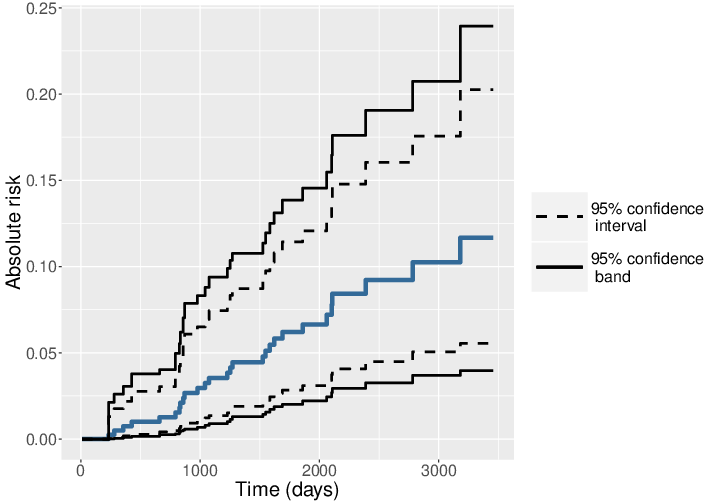

Figure 3: Absolute risk over time for a 45 years old female patient with a tumor thickness of 0.1 mm and epithelioid cells (blue line). The continuous black lines represent the confidence bands while the dashed black lines represent the range of the confidence intervals.

```r
figure3 <- autoplot(pfit1band, band = TRUE, ci = TRUE)$plot
figure3 <- figure3 + xlab("Time (days)") + ylab("Absolute risk")
print(figure3)
```

Note that the resulting object is a `"ggplot"` graphic. This can be useful to personalize the graph, e.g. change the font size of the text.

# Construction of the confidence intervals

In this section we describe the asymptotic formula behind the confidence intervals for the predicted absolute risks and the empirical counterpart which is implemented in *riskRegression*. We assume a sample $(\mathcal{X}_i)_{i \in \{1,\ldots,n\}}$ of $n$ independent and identically distributed replications of $\mathcal{X} = (\tilde T,\tilde D,X,Z)$. The estimator $\hat F_1$ of $F_1$ is obtained by substituting the Cox partial likelihood estimate $\hat\beta_j$ for $\beta_j$ and the baseline hazard estimate $\hat\lambda_{0j,z}$ for $\lambda_{0j,z}$ in equations @ref(eq:sHazard) and @ref(eq:absRisk).

The asymptotic confidence intervals for the covariate specific absolute risks of event 1 before time $t$ are based on the following von Mises expansion (van der Vaart 1998):
$$\label{iid_absRisk}
\sqrt{n}(\hat{F}_1(t|x,z) - F_1(t|x,z)) = \frac{1}{\sqrt
n}\sum_{i=1}^{n} \phi_{F_1}(\mathcal{X}_i;t,x,z) + o_{\mathrm
P}(1). (\#eq:iid-absRisk)$$
where the exponential approximation is used for defining the event free survival in $F_1(t|x,z)$. Given @ref(eq:iid-absRisk), for fixed values $t,x,z$ the central limit theorem implies that $\hat F_1(t|x,z)$ has an asymptotic normal distribution with asymptotic variance $V_{F_1}(t,x,z)=\mathrm E(\phi_{F_1}(\mathcal{X}_i;t,x,z)^2)$. Based on the estimate $\widehat{\phi}_{F_1}$ of the influence function $\phi_{F_1}$ (both defined in subsequent subsections) our variance estimate is given by
$$\label{var_absRisk}
\widehat V(t,x,z) ={\frac{1}{n}}\sum_{i=1}^{n}
\widehat{\phi}_{F_1}(\mathcal{X}_i;t,x,z)^2. (\#eq:var-absRisk)$$
We then construct Wald confidence intervals for $F_1(t|x,z)$ in the usual way:
$$\left[ F_1(t|x,z) + q_{\alpha/2}\sqrt{\widehat
V(t,x,z))}; F_1(t|x,z) + q_{1-\alpha/2} \sqrt{\widehat V(t,x,z)}
\right]$$
where $q_{\alpha}$ is the $\alpha$-quantile of the normal distribution. Since the absolute risk is bounded below by $0$ and above by $1$, the confidence interval is automatically restricted to this interval. Alternatively the confidence interval can be computed using a log-log transformation: first the confidence interval is computed on the log-log scale:
$$\left[ \log(-\log(F_1(t|x,z)) ) +
q_{\alpha/2}\sqrt{\widehat V_{log-log}(t,x,z))}; \log(-\log(F_1(t|x,z))
) - q_{1-\alpha/2} \sqrt{\widehat V_{log-log}(t,x,z)} \right]$$
where $V_{log-log}$ is the variance of the influence function on the log-log scale. Then the confidence interval is back transformed using the link function: $x \mapsto \exp(-\exp(x))$. This ensures that the confidence interval is bounded below by $0$ and above by $1$. By default, the confidence intervals are computed using the log-log transformation. To compute them without using the log-log transformation, the argument `log.transform` needs to be set to `FALSE` when calling `predict.CauseSpecificCox()`:

```r
pfit2se <- predict(cfit1, newdata = newdata, cause = 1, times = c(867,3500),
           se = TRUE, log.transform = FALSE, keep.newdata = FALSE)
print(pfit2se)
```

```r
##    observation times     strata absRisk absRisk.se absRisk.lower absRisk.upper
## 1:           1   867 sex=Female   0.021    0.00992       0.00157        0.0404
## 2:           2   867   sex=Male   0.149    0.04586       0.05945        0.2392
## 3:           1  3500 sex=Female   0.117    0.03795       0.04226        0.1910
## 4:           2  3500   sex=Male   0.428    0.11620       0.20021        0.6557
```

## Asymptotic formula

The influence function $\phi_{F_1}$ can be expressed as a function of the influence functions $\phi_{\lambda_1}$ and $\phi_{\lambda_2}$ of the cause-specific hazard rates:
$$\begin{gathered}
\label{IF_absRisk}
\phi_{F_1}(\mathcal{X},t,x,z) = \int_{0}^{t}
\exp(-\Lambda_{1,z}(s|x)-\Lambda_{2,z}(s|x))
d\phi_{\Lambda_{1,z}}(\mathcal{X};s,x) \\
- \int_{0}^{t} \lambda_{1,z}(s|x)
\exp(-\Lambda_{1,z}(s|x)-\Lambda_{2,z}(s|x)) \left(
\phi_{\Lambda_{1,z}}(\mathcal{X};s,x) +
\phi_{\Lambda_{2,z}}(\mathcal{X};s,x) \right) ds.
\end{gathered} (\#eq:IF-absRisk)$$
We use the shorthand notations $v^{\otimes 0}=0, v^{\otimes 1}=v, v^{\otimes 2}=v{v}^\intercal$ and
$$\int f(s,d,v,w)\mathrm d\mathrm P(s,d,v,w) =
\int_0^\infty\sum_{d=0}^K\int_{R^p}\sum_{z=1}^L
f(s,d,v,w)\mathrm d\mathrm P(s,d,v,w).$$
We also suppress the dependence on $\tau$ when we in the following adapt the usual notation for Cox model asymptotic theory to the cause-specific and stratified case:
$$\begin{aligned}
\mathcal{S}^{(r)}(t,\beta_j,z) &= \int 1\{t \le s\le \tau,w=z\}\exp
(v \beta_j) v^{\otimes r} \mathrm d\mathrm P(s,d,v,w)\\
E(t,\beta_j,z) &=
\frac{\mathcal{S}^{(1)}(t,\beta_j,z)}{\mathcal{S}^{(0)}(t,\beta_j,z)}\\
\mathcal{I}(\beta_j) &= \int 1\{d=j\}
\left(\frac{\mathcal{S}^{(2)}(s,\beta_l,w)}{\mathcal{S}^{(0)}(s,\beta_j,w)}
- E(s,\beta_j,w)^{\otimes 2}\right)\mathrm d\mathrm P(s,d,v,w).
\end{aligned}$$

For fixed cause $j$, time $t$ and strata $z$ the expansions $\sqrt n (\hat \beta_j -\beta_j) = \frac{1}{\sqrt n} \sum_{i=1}^n \phi_{\beta_{j}}(\mathcal X_i) + o_{\mathrm P}(1)$ and $\sqrt n (\hat \Lambda_{0j,z}(t) -\Lambda_{0j,z}(t)) = \frac{1}{\sqrt n} \sum_{i=1}^n \phi_{\Lambda_{0j,z}}(\mathcal X_i,t)+ o_{\mathrm P}(1)$ are then characterized by the influence functions
$$\begin{aligned}
\phi_{\beta_{j}}(\mathcal X) &= \mathcal{I}(\beta_j)^{-1}
\biggl(1\{\tilde D=j,\tilde T<\tau\}\left(X - E(\tilde
T,\beta_j,Z)\right) \notag\\
&\quad - \exp (X \beta_j) \int 1\{d=j,s\leq\tilde T\} \frac{X -
E(s,\beta_j,Z)}{\mathcal{S}^{(0)}(s,\beta_j,Z)}\mathrm
dP(s,d,v,w)\biggr) \label{IF_beta} \\
\end{aligned} (\#eq:IF-beta)$$

$$\begin{aligned}
\phi_{\Lambda_{0j,z}}(\mathcal X;t) &= - \phi_{\beta_j}(\mathcal X)
\int_0^t E(s,\beta_j,z) \lambda_{0j,z}(s) ds \notag \\
& \quad - 1\{Z=z\} \biggl(\exp (X \beta_j) \int_0^{min(t,\tilde T)}
\frac{\lambda_{0j,z}(s) }{\mathcal{S}^{(0)}(s,\beta_j,z)} ds
- \frac{1\{\tilde{T} \leq t,\tilde
D=j\}}{\mathcal{S}^{(0)}(\tilde{T},\beta_j,Z)} \biggr).
\label{IF_cumHazard}
\end{aligned} (\#eq:IF-cumHazard)$$

In absence of strata, formula @ref(eq:IF-beta) is equal to formula 2 of (Reid 1981) and formula @ref(eq:IF-cumHazard) equals the one given in T. Gerds and Schumacher (2001) [top of page 576; note however that there is a sign mistake in their first term]. To connect these formulas with formula @ref(eq:IF-absRisk) it remains to note that under the Cox regression model the influence function of the cause-specific hazard rate can be written as:
$$\label{IF_lambda}
\phi_{\Lambda_{j,z}}(\mathcal{X};t,x) = \exp(x\beta_j) \left(
\phi_{\Lambda_{0j,z}}(\mathcal{X};t)
+ \Lambda_{0j,z}(t)\; x \; {\phi_{\beta_j}(\mathcal{X})}^\intercal
\right). (\#eq:IF-lambda)$$

## Empirical estimates

The following formulas are obtained with the plug-in principle substituting the Cox partial likelihood estimates $\hat{\beta}_j$ for $\beta_j$ and the baseline hazard estimates $\hat{\lambda}_{0j,z}$ for $\lambda_{0j,z}$ into formulas @ref(eq:IF-absRisk) - @ref(eq:IF-lambda). We denote by $N^z_j(t)=\sum_{i=1}^n 1\{\tilde T_i \le t, \tilde D_i=j, Z_i=z\}$ the strata and cause specific counting process, and by $Y^{z}(t)=\sum_{i=1}^n 1\{T_i \geq t, Z_i=z\}$ the strata specific “at-risk” process (Andersen et al. 1993). The empirical estimate of the influence function of the partial likelihood estimate is given by
$$\begin{aligned}
\widehat{\phi}_{\beta_{j}}(\mathcal X_i)
&= \widehat{\mathcal{I}}(\beta_j)^{-1}
\biggl( \Delta_i \left(X_i - \hat{E}(\tilde
T_i,\hat{\beta}_j,Z_i)\right) - \exp (X_i \hat{\beta}_j) \int_0^{T_i}
\frac{X_i -
\hat{E}(s,\hat{\beta}_j,Z_i)}{\widehat{\mathcal{S}^{(0)}}(s,\hat{\beta}_j,Z_i)}\mathrm
dN_j(s)\biggr)
\end{aligned}$$
where
$$\begin{aligned}
\widehat{\mathcal{S}^{(r)}}(t,\hat{\beta}_j,z) &= \int_0^\tau \exp
(X_i \hat{\beta}_j) X_i^{\otimes r}\mathrm dN^z_j(t).
\end{aligned}$$
The influence functions for the cumulative baseline hazard and its first differential are estimated by:
$$\begin{aligned}
\widehat{\phi}_{\Lambda_{0j,z}}(\mathcal X_i;t) &= -
\widehat{\phi}_{\beta_j}(\mathcal X_i) \int_0^t
E(s,\hat{\beta}_j,z) \hat{\lambda}_{0j,z}(s)\mathrm ds \notag \\
& \quad - 1\{Z_i=z\} \biggl( \exp (X_i \hat{\beta}_j) \int_0^{min(t,
\tilde T_i)} \frac{\hat{\lambda}_{0j,z}(s)
}{\widehat{\mathcal{S}^{(0)}}(s,\hat{\beta}_j,z)} ds
- \frac{1\{\tilde{T}_i \leq t,\tilde
D_i=j\}}{\widehat{\mathcal{S}^{(0)}}(\tilde{T}_i,\hat{\beta}_j,Z_i)}
\biggr) \label{empiricalIF_Lambda0}\\
\end{aligned} (\#eq:empiricalIF-Lambda0)$$

$$\begin{aligned}
d\widehat{\phi}_{\Lambda_{0j,z}}(\mathcal X_i;t) &= -
\widehat{\phi}_{\beta_j}(\mathcal X_i)
E(t,\hat{\beta}_j,z) \hat{\lambda}_{0j,z}(t) \notag \\
& \quad - 1\{Z_i=z\} \biggl( \exp (X_i \hat{\beta}_j) 1\{t \leq
\tilde T_i\} \frac{\hat{\lambda}_{0j,z}(t)
}{\widehat{\mathcal{S}^{(0)}}(t,\hat{\beta}_j,z)}
- \frac{1\{\tilde T_i= t,\tilde
D_i=j\}}{\widehat{\mathcal{S}^{(0)}}(\tilde{T_i},\hat{\beta}_j,Z_i)}
\biggr). \label{empiricalIF_lambda0}
\end{aligned} (\#eq:empiricalIF-lambda0)$$
These estimates lead to the following estimates of the influence functions of the covariate specific cumulative hazard and its derivative relative to the time:
$$\begin{aligned}
\label{empiricalIF_Lambda}
\hat{\phi}_{\Lambda_{j,z}}(\mathcal{X}_i;t,x) &=
\exp(x\hat{\beta}_j) \left(
\widehat{\phi}_{\Lambda_{0j,z}}(\mathcal{X}_i;t)
+ \hat{\Lambda}_{0j,z}(t)\; x \;
{\widehat{\phi}_{\beta_j}(\mathcal{X}_i)}^\intercal \right) \\
\end{aligned} (\#eq:empiricalIF-Lambda)$$

$$\begin{aligned}
\label{empiricalIF_lambda}
d\hat{\phi}_{\Lambda_{j,z}}(\mathcal{X}_i;t,x) &=
\exp(x\hat{\beta}_j) \left(
d\widehat{\phi}_{\Lambda_{0j,z}}(\mathcal{X}_i;t)
+ \hat{\lambda}_{0j,z}(t)\; x \;
{\widehat{\phi}_{\beta_j}(\mathcal{X}_i)}^\intercal \right).
\end{aligned} (\#eq:empiricalIF-lambda)$$
Finally, we obtain our estimate of the influence function of the absolute risk:
$$\begin{aligned}
\label{empiricalIF_risk}
& \widehat{\phi}_{F_1}(\mathcal{X}_i,t,x,z) = \int_0^t
\exp(-\hat{\Lambda}_{1,z}(s|x)-\hat{\Lambda}_{2,z}(s|x))
d\widehat{\phi}_{\Lambda_{1,z}}(\mathcal{X}_i;s,x) \\
& - \int_0^t \hat{\lambda}_{1,z}(s|x)
\exp(-\hat{\Lambda}_{1,z}(s|x)-\hat{\Lambda}_{2,z}(s|x))
\biggl(\widehat{\phi}_{\Lambda_{1,z}}(\mathcal{X}_i;s,x) +
\widehat{\phi}_{\Lambda_{2,z}}(\mathcal{X}_i;s,x) \biggr)\mathrm ds.
\end{aligned} (\#eq:empiricalIF-risk)$$

# Construction of the confidence bands

A confidence band with confidence level $1-\alpha$ for the absolute risk $F_1(.|x,z)$ restricted to the time interval $\mathcal{T} = [\tau_1;\tau_2]$ is a region $R_{\mathcal{T}}(x,z) = \left[l_{x,z}(t);u_{x,z}(t)\right]_{t\in\mathcal{T}}$ satisfying:
$$\mathrm P( F_1(t|x,z) \in
\left[ l_{x,z}(t) ; u_{x,z}(t)\right] | \forall t \in \mathcal{T}) =
1-\alpha.$$

In figure 3, $\tau_1=0$ and $\tau_2=3458$, the time at which the last event occurred. Using the martingale central limit theorem, (Cheng, Fine, and Wei 1998) have shown that $\hat{F}_1(t|x,z)-F_1(t|x,z)$ converges weakly to a zero-mean Gaussian process on $\mathcal{T}$. The asymptotic variance of this process is $V(t,x,z)$. However the $1-\alpha$ quantile achieving simultaneous coverage is larger than the $1-\alpha$ quantile of a standard normal distribution. Since the dependence between the increments of the process $\hat{F}_1(t|x,z)-F_1(t|x,z)$ makes the derivation of an explicit expression for the quantile difficult, we used instead a resampling technique (Thomas H. Scheike and Zhang 2008). Consider over $t \in \mathcal{T}$ the normalized process:
$$\psi_{F_1}(\mathcal{X}_i;t,x,z) =
\phi_{F_1}(\mathcal{X}_i;t,x,z)/\sqrt{V(t,x,z)}.$$
Denote by $c_{1-\alpha/2}$ the $1-\alpha/2$ quantile of the sample:
$$\sup_{t\in\mathcal{T}}\left|
\psi_{F_1}(\mathcal{X}_i;t,x,z) \right|$$
and using the symmetry of the Gaussian distribution, i.e. $c_{\alpha/2} = - c_{1-\alpha/2}$, a $1-\alpha$ confidence band over $\mathcal{T}$ is constructed as follows:
$$\begin{aligned}
\left[ F_1(t|x,z) - c_{1-\alpha/2}\sqrt{\widehat V(t,x,z))}; F_1(t|x,z)
+ c_{1-\alpha/2} \sqrt{\widehat V(t,x,z)} \right].
\end{aligned}$$
Like for the confidence intervals, the confidence bands will be restricted to the interval
$$0;1$$
when they are not computed using a log-log transformation.

# Implementation details

The function `predict.CauseSpecificCox()` calls two important functions, `predictCox()` that computes the hazard and cumulative hazard for a fitted Cox model, and `iidCox()` that computes the influence function for the baseline hazard and regression coefficients. In this section we first explain how `predictCox()` deals with ties in the event times. We then show that the function `predictCox()` can also be used to obtain confidence intervals and bands for covariate specific survival probabilities in the situation without competing risks. Implementation details about the function `iidCox()` are postponed to appendix B. These details may be useful for programmers who need to care about memory usage.

## Handling of tied event times

We speak of ties when two or more observations have the same value of the time variable $\tilde T$. Ties occur for example when time is recorded on a discrete scale such as months. The *survival* package implements three different methods to deal with ties (“efron”, “breslow”, and “exact”, see `help(coxph)`) for the partial likelihood estimator of the log hazard ratios $\beta_j$ (T. M. Therneau and Grambsch 2000). We have implemented the “efron” and the “breslow” method but not the “exact” method. For a comparison of these methods and yet another method see (T. H. Scheike and Sun 2007). We now state the formula for the baseline hazard function under Breslow’s (Breslow 1974) and Efron’s method (Efron 1977) for the handling of ties. The baseline hazard estimate in strata $z$ given by the Breslow method is:
$$d\hat\Lambda_{0j,z}^B(t)= \frac{\mathrm
dN^z_{j}(t)}{\sum_{i \in Y^{z}(t)} \exp(\beta^t X_i)}.$$
With the Efron method for handling ties the formula is given by:
$$d\hat{\Lambda}_{0j,z}^E(t)=\sum^{\mathrm
dN^z_{j}(t)}_{k=1}
\frac{1}{\sum_{i \in Y^{z}(t)} \exp(\beta^t X_i)-
\frac{k-1}{\mathrm dN^z_{j}(t)}\sum^{\mathrm dN^z_{j}(t)}_{i=1}
\exp(\beta^t X_i)}.$$

Both estimators are implemented in the function `predictCox()` which provides estimates of the baseline hazard, the cumulative baseline hazard and baseline survival. The `predictCox()` function does not have an argument to specify whether Breslow method or Efron method should be used; instead it uses the same method that has been used to estimate the regression coefficients. In the case of the `coxph()` function, the default method is Efron:

```r
f1 <- coxph(Surv(time,status != 0) ~ age + logthick + epicel + strata(sex),
            data = Melanoma, x = TRUE, y = TRUE)
f1$method
```

```r
## [1] "efron"
```

Therefore the baseline hazard will be estimated using the Efron method when calling `predictCox()`:

```r
baseH1 <- predictCox(f1)
as.data.table(baseH1[c("time","cumhazard","strata","survival")])
```

```r
##      time  cumhazard strata  survival
##   1:   99 0.00623279 Female 0.9937866
##   2:  232 0.01256406 Female 0.9875145
##   3:  279 0.01897728 Female 0.9812017
##   4:  295 0.02555481 Female 0.9747690
##   5:  355 0.03221850 Female 0.9682950
##  ---
## 199: 3909 0.69673810   Male 0.4982078
## 200: 4119 0.69673810   Male 0.4982078
## 201: 4207 0.69673810   Male 0.4982078
## 202: 4310 0.69673810   Male 0.4982078
## 203: 4492 0.69673810   Male 0.4982078
```

The cumulative baseline hazard and baseline survival are displayed in the columns “cumHazard”, and “survival” of the output. This corresponds, respectively, to $\Lambda_{0j,z}(t)$ and $exp(-\Lambda_{0j,z}(t))$ where $j$ is 1, $z$ can be found in the column “strata” and $t$ in “time”. The covariate specific cumulative hazard $\Lambda_{j,z}(t|x)$ and survival $exp(-\Lambda_{j,z}(t|x))$ can be estimated using the same function:

```r
predictCox(f1, newdata = Melanoma[c(17,101,123),],
       times = c(7,3,5)*365.25)
```

```r
##    observation times strata cumhazard survival
## 1:           1  2557   Male     0.884    0.413
## 2:           2  2557 Female     0.555    0.574
## 3:           3  2557 Female     0.949    0.387
## 4:           1  1096   Male     0.453    0.635
## 5:           2  1096 Female     0.202    0.817
## 6:           3  1096 Female     0.346    0.708
## 7:           1  1826   Male     0.670    0.512
## 8:           2  1826 Female     0.366    0.693
## 9:           3  1826 Female     0.626    0.535
```

## Confidence intervals and confidence bands for survival probabilities

In absence of competing risks, the influence function of a Cox model can be used to estimate confidence intervals for the survival. This can be done by setting the argument `se` to `TRUE` when calling the `predictCox()` function:

```r
p1 <- predictCox(f1, newdata = Melanoma[3:5,],
         times = c(Melanoma$time[5:7],1000),
         se = TRUE, type="survival")
```

The `predictCox()` function output an object of class `"predictCox"`. The `print()` method can be used to display the confidence intervals for the survival computed at different times:

```r
print(p1)
```

```r
##     observation times strata survival survival.se survival.lower survival.upper
##  1:           1   185   Male    0.980       0.616          0.935          0.994
##  2:           2   185 Female    0.985       1.014          0.893          0.998
##  3:           3   185   Male    0.947       0.652          0.823          0.985
##  4:           1   204   Male    0.973       0.567          0.921          0.991
##  5:           2   204 Female    0.985       1.014          0.893          0.998
##  6:           3   204   Male    0.929       0.594          0.791          0.977
##  7:           1   210   Male    0.967       0.503          0.913          0.987
##  8:           2   210 Female    0.985       1.014          0.893          0.998
##  9:           3   210   Male    0.912       0.552          0.762          0.969
## 10:           1  1000   Male    0.864       0.321          0.760          0.925
## 11:           2  1000 Female    0.769       0.286          0.631          0.860
## 12:           3  1000   Male    0.673       0.391          0.426          0.832
```

Here the confidence intervals were computed using a log-log transformation. The argument `log.transform` can be set to `FALSE` to compute them without using the log-log transformation. Confidence bands can also be obtained using `predictCox()` by setting the argument `band` to `TRUE`. As for the `predict.CauseSpecificCox()` function, 10,000 simulations will be used to compute the confidence bands; this can be changed specifying the argument `nsim.band`. The function `as.data.table.predictCox()` makes it easy to extract subsets from `"predictCox"` object:

```r
p1 <- as.data.table(p1)
p1[times == 185,]
```

```r
##    observation times strata  survival survival.se survival.lower survival.upper
## 1:           1   185   Male 0.9801395   0.6163925      0.9350597      0.9940246
## 2:           2   185 Female 0.9845660   1.0137483      0.8927600      0.9978695
## 3:           3   185   Male 0.9470887   0.6524116      0.8226132      0.9849795
```

# Coverage of the confidence interval and the confidence bands

As expected, the coverage of the confidence intervals is improving with increasing sample size and reaches its nominal level of 95% at around sample size 1000 (figure 4, left panel). Using a log-log transformation leads to better small sample properties and similar large sample properties (figure 4, right panel). A larger sample size was necessary for the confidence bands to converge toward the nominal coverage level (n = 5000, figure 5 left panel). Again log-log transformation leads to better small sample properties. We only displayed here the coverage for the absolute risk but similar coverage was obtained for the survival function.

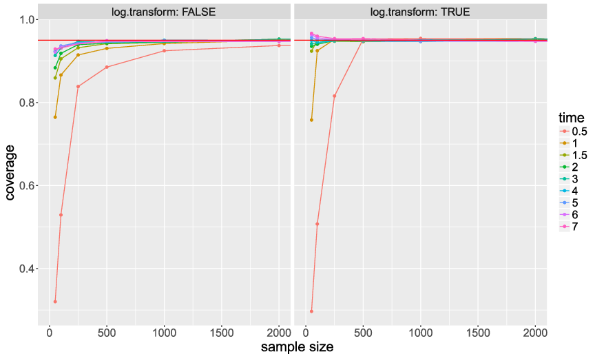

Figure 4: Coverage of the asymptotic confidence interval of the absolute risk plotted against the sample size. Each color corresponds to a prediction time. The figure is only shown for samples size below 2000 since for larger sample sizes the coverage is always approximately equal to $0.95$. Left panel: confidence intervals are computed on the original scale. Right panel: confidence intervals are computed on the log-log scale and back-transformed.

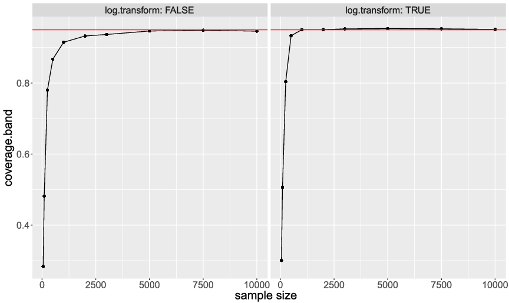

Figure 5: Coverage of the asymptotic confidence band of the absolute risk plotted against the sample size. Left panel: confidence intervals are computed on the original scale. Right panel: confidence intervals are computed on the log-log scale and back-transformed.

# Runtime and memory usage

## Baseline hazard

We compare the performance of `predictCox()` regarding the estimate of the baseline hazard function with that of the function `survival::basehaz()`. For this purpose we simulate data with 10 covariates including both continuous and discrete type using the `sampleData()`.

In our performance study we vary the sample size ranging from 500 to 1,000,000 observations and consider both stratified:

```r
Surv(time,event) ~ strata(X1) + X2 + X3 + X4 + X5 + X6 + X7 + X8 + X9 + X10
```

and non-stratified Cox regression models:

```r
Surv(time,event) ~ X1 + X2 + X3 + X4 + X5 + X6 + X7 + X8 + X9 + X10
```

The computation times were estimated using the [*rbenchmark*](https://CRAN.R-project.org/package=rbenchmark) package (Kusnierczyk 2012) and averaged across 100 simulated data sets. The memory usage was estimated using the [*profvis*](https://CRAN.R-project.org/package=profvis) package (Chang and Luraschi 2017) and averaged across 10 simulations. When the execution time of the function was extremely fast (i.e. <0.005s), the memory usage could not be reliably assessed and was set to `NA`.

Memory usage and computation time are displayed on figure 6 and 7. Both functions lead to a reasonable computation time (<1 min) even when considering very large datasets (e.g. >10,000 observations). Nevertheless the `predictCox()` function outperforms the `basehaz()` function by a factor varying between $3$ and $11$ in terms of computation time. The gain in speed is especially expressed in large datasets. Memory usage is also lower for `predictCox()` and decreases by a factor between $1$ and $1.6$ as compared to `basehaz()`.

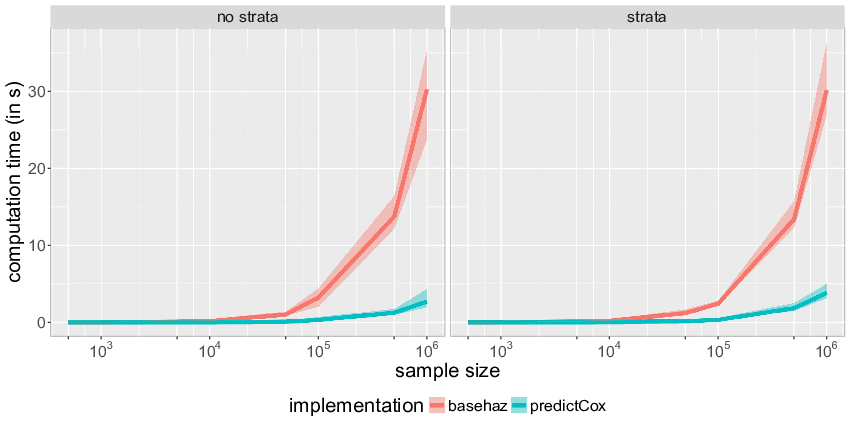

Figure 6: The computation time (in seconds) of `predictCox()` and `basehaz()` plotted against the sample size for a Cox model (left panel) and a stratified Cox model (right panel). The x axis is displayed using a logarithmic scale but its labels refer to the (untransformed) sample size. The curves represent the median values over 100 simulations while the shaded areas represent the 95% confidence intervals.

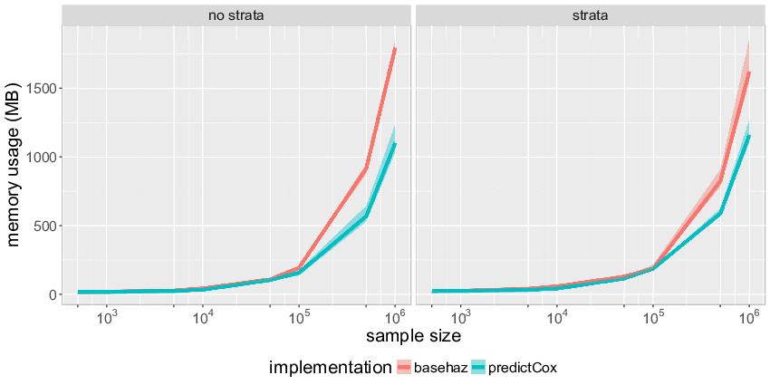

## Absolute risk

We now compare two implementations for computing the standard errors of the absolute risk. The default implementation corresponds to setting the argument `store.iid` to `"full"` when calling `predict.CauseSpecificCox()` or `predictCox()` while the second is obtained by setting `store.iid` to `"minimal"`. The two implementations are described in more detail appendix B.

First we compare their computation time and memory consumption when making only one prediction. As before, we simulated datasets for $K=2$ using the `SimCompRisk()` function with increasing sample size. Then, the two cause-specific Cox models were fitted to each of the simulated datasets using `riskRegression::CSC`. Then we measured the computation time and memory usage necessary to estimate the absolute risk with its standard error for the first observation at time 4, when using the argument `store.iid="minimal"` or `store.iid="full"` in `predict.CauseSpecificCox()`.

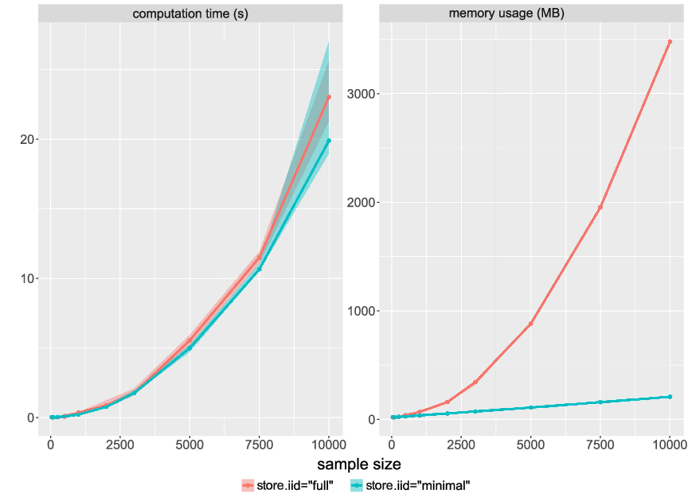

Figure 8: The computation time (left panel) and memory usage (right panel) for computing the absolute risk with its standard error for one observation plotted against the sample size, setting the argument `store.iid` to `"full"` or `"minimal"` when calling `predict.CauseSpecificCox()`. The curves represent the median values over 100 simulations while the shaded areas represent the 95% confidence intervals.

# Summary

This paper introduces new features of the *riskRegression* package for prediction of absolute risks from cause-specific Cox regression models using computationally efficient functions. 1 summarizes the main functions described in this paper. Confidence intervals and confidence bands for the absolute risks can be computed using the `predict()` function and displayed using the `print()` method. The `predictCox()` function can be applied on `"coxph"` and `"cph"` objects to predict the survival with its confidence interval or confidence bands. In both cases, the `autoplot()` function can display the predicted risk (or survival) over time. When dealing with small to moderate sample sizes, we advise to compute confidence intervals or confidence bands using a log-log transformation (argument `log.transform`).

Table 1: Functions implemented in the *riskRegression* package for making prediction from Cox regression models

| `CSC()` | Fit cause-specific Cox models |
| --- | --- |
| `predict()` | Predict covariate specific absolute risks for given time horizons |
| `iidCox()` | Compute the influence function of the baseline hazard estimator and of the partial likelihood estimator of the regression coefficients |
| `predictCox()` | Compute the (cumulative) baseline hazard function and predictions of hazards and survival probabilities in new data |
| `autoplot()` | Graphical display of the predicted risk across time |

# Appendix A Modularity

The `CSC()` function requires a routine to estimate the regression coefficients of the Cox model. By default, `CSC()` calls the `coxph()` function from the *survival* package to do so. This has several reasons: `coxph()` has been thoroughly tested, is reasonably fast, widely used and provides flexible modeling options. However in specific contexts, other routines may be more appropriate, e.g. faster. Also, developers that have implemented their own routine may be interested in computing the baseline hazard or the influence function.

To be able to apply the `predictCox()` and `iidCox()` functions on new classes, one needs to define the methods extracting the necessary information from the new class. For instance, the [*mets*](https://CRAN.R-project.org/package=mets) package (Holst and Scheike 2017) contains an efficient routine for estimating Cox models. However `"phreg"` object that are quite different from `"coxph"` objects:

```r
library(mets, verbose = FALSE)
Melanoma$entry <- 0
f1.phreg <- phreg(Surv(entry, time, status != 0) ~ age + logthick + epicel +
              strata(sex), data = Melanoma)
list(coxph=names(f1),
     phreg=names(f1.phreg))
```

```r
## $coxph
##  [1] "coefficients"      "var"               "loglik"            "score"
##  [5] "iter"              "linear.predictors" "residuals"         "means"
##  [9] "concordance"       "method"            "n"                 "nevent"
## [13] "terms"             "assign"            "wald.test"         "x"
## [17] "strata"            "y"                 "formula"           "xlevels"
## [21] "contrasts"         "call"
##
## $phreg
##  [1] "coef"        "ploglik"     "gradient"    "hessian"     "U"           "S0"
##  [7] "nevent"      "ord"         "time"        "jumps"       "jumptimes"   "strata"
## [13] "entry"       "exit"        "status"      "p"           "X"           "id"
## [19] "opt"         "call"        "model.frame"
```

Therefore to be able to use the `predictCox()` and `iidCox()` functions on `"phreg"` one needs to define methods to extract:

**The values used to center the covariates**

(`CoxCenter()` method). Instead of working on $X$, many routines estimating the Cox model parameters works on a centered version $\tilde X = X-\bar{X}$. The `CoxCenter()` method returns $\bar{X}$:

```r
riskRegression:::coxCenter.coxph(f1)
```

```r
##        age      logthick epicelpresent
## 52.4634146     0.6181706     0.4341463
```

**The design matrix used to fit the Cox model**

(`CoxDesign()` method). The first two columns describe the beginning and the end of the interval of time when the individual was followed. The third contains the event type (0 corresponding to censoring and 1 to an observed event, e.g. death). The remaining columns contain the design matrix corresponding to the coefficients $\beta$ of the Cox model and the strata variable (if any):

```r
head(riskRegression:::coxDesign.coxph(f1))
```

```r
##   start stop status age   logthick epicelpresent strata
## 1     0   10      1  76  1.9110229             1      2
## 2     0   30      1  56 -0.4307829             0      2
## 3     0   35      0  41  0.2926696             0      2
## 4     0   99      1  71  1.0647107             0      1
## 5     0  185      1  52  2.4915512             1      2
## 6     0  204      1  28  1.5769147             0      2
```

**The formula of the Cox model**

(`CoxFormula()` method):

```r
riskRegression:::coxFormula.coxph(f1)
```

```r
Surv(time, status != 0) ~ age + logthick + epicel + strata(sex)
```

**The value of the linear predictor**

$X\beta$ (`CoxLP()` method). This function has three arguments: `object`, `data`, and `center`.

```r
head(riskRegression:::coxLP.coxph(f1, data = NULL, center = FALSE))
```

```r
## [1] 2.433793 1.136828 1.168604 2.332216 2.165533 1.559629
```

When setting `data` to `NULL`, the `CoxLP()` method will return the linear predictor computed on the dataset used to fit the Cox model. The `center` argument indicates whether the covariates should be centered before computing the linear predictor.

**The number of observations used to fit the Cox model**

(`CoxN()` method):

```r
riskRegression:::coxN.coxph(f1)
```

```r
## [1] 205
```

**The character string indicating the strata variable(s) in the formula**

(`CoxSpecialStrata()` method):

```r
riskRegression:::coxSpecialStrata.coxph(f1)
```

```r
## [1] "strata"
```

**The variable encoding to which strata belongs each observation**

(`CoxStrata()` method). This variable must be univariate, aggregating all the strata variables.

```r
head(riskRegression:::coxStrata.coxph(f1, data = NULL, strata.vars = "strata(sex)"))
```

```r
## [1] Male   Male   Male   Female Male   Male
## Levels: Female Male
```

Similarly to `CoxLP()`, when setting `data` to `NULL`, the `CoxStrata()` method will return the strata variable computed on the dataset used to fit the Cox model.

**The variance-covariance matrix of the regression coefficients**

(`CoxVarCov()` method):

```r
riskRegression:::coxVarCov.coxph(f1)
```

```r
##                         age      logthick epicelpresent
## age            6.553939e-05 -0.0002102408 -0.0004363469
## logthick      -2.102408e-04  0.0206977373  0.0076882093
## epicelpresent -4.363469e-04  0.0076882093  0.0692047486
```

Most of the above methods correspond to a very small piece of code that reformats the information contained in the object, e.g.:

```r
riskRegression:::coxVarCov.coxph
```

```r
## function (object)
## {
##     Sigma <- object$var
##     if (!is.null(Sigma)) {
##         coefName <- names(coef(object))
##         colnames(Sigma) <- coefName
##         rownames(Sigma) <- coefName
##     }
##     return(Sigma)
## }
## <environment: namespace:riskRegression>
```

We refer to the help page of each method for a more precise description of each method arguments and expected output, as well as examples. Once all of the methods have been defined for a new object (e.g. `"phreg"`), `predictCox()` and `iidCox()` can be applied on the new object:

```r
all.equal(predictCox(f1), predictCox(f1.phreg))
```

```r
## [1] TRUE
```

```r
all.equal(iidCox(f1), iidCox(f1.phreg))
```

```r
## [1] TRUE
```

# Appendix B Saving the influence functions

The function `iidCox()` computes the estimates of the influence functions $\phi_{\beta_j}$, $\phi_{\lambda_{0j}}$, and $\phi_{\Lambda_{0j}}$ for a given set of covariates and time points:

```r
f1.iid <- iidCox(f1)
```

The default implementation (`store.iid="full"`) stores the influence function for the baseline cumulative hazard as a list of matrices, one for each strata. The size of each matrix is the number of observations $n$ times the number of unique event times $n_T(z)$ in stratum $z$. Storing the influence function can be very memory demanding when considering large datasets. This is why the influence function is only temporary stored during the execution of the `predict()` method.

When dealing with very large datasets, e.g. following $n=20 000$ patients during $n_T=365$ days, storing the influence function can be too memory demanding. Instead of computing and storing $\phi_{\lambda_{0j}}$, an alternative solution is to only store the necessary quantities to compute $\phi_{\lambda_{0j}}$:
$$\label{IFstoreMin}
\frac{1\{\tilde T_i= t,\tilde
D_i=j\}}{\widehat{\mathcal{S}^{(0)}}(\tilde{T_i},\hat{\beta}_j,Z_i)}, \;
E(t,\hat{\beta}_j,z) \hat{\lambda}_{0j,z}(t), \;
\int_0^t E(s,\hat{\beta}_j,z) \hat{\lambda}_{0j,z}(s)\mathrm ds, \;
\frac{\hat{\lambda}_{0j,z}(t)
}{\widehat{\mathcal{S}^{(0)}}(t,\hat{\beta}_j,z)}, \;
\int_0^t \frac{\hat{\lambda}_{0j,z}(s)
}{\widehat{\mathcal{S}^{(0)}}(s,\hat{\beta}_j,z)}
ds. (\#eq:IFstoreMin)$$
These quantities are lists containing $L$ vectors of length $n$ or $n_T(z)$. Since in most applications $n$ and $n_T(z)$ are large compared to $L$ this approach is much more memory efficient. Setting the argument `store.iid` to `"minimal"` when calling `iidCox` will return the influence function using this alternative storage method:

```r
f2.iid <- iidCox(f1, store.iid = "minimal")
```

We can compare the memory cost of the default implementation vs. the alternative one:

```r
size.f1.iid <- object.size(f1.iid$IFcumhazard)
size.f2.iid <- object.size(f2.iid$calcIFhazard)
as.numeric(size.f2.iid/size.f1.iid)
```

```r
## [1] 0.08627399
```

and see that the memory use for storing the influence function of the cumulative hazard has been divided by more than 10.

Computing the influence function of the absolute risk with the default implementation only requires to:

- use $\widehat{\phi}_{\Lambda_{0j,z}}(\mathcal{X}_i;t)$ and $d\widehat{\phi}_{\Lambda_{0j,z}}(\mathcal{X}_i;t)$ with formula @ref(eq:empiricalIF-Lambda) and @ref(eq:empiricalIF-lambda) to obtain $\hat{\phi}_{\Lambda_{j,z}}(\mathcal{X}_i;t,x)$ and $d\hat{\phi}_{\Lambda_{j,z}}(\mathcal{X}_i;t,x)$.
- use formula @ref(eq:empiricalIF-risk) to obain $\widehat{\phi}_{F_1}(\mathcal{X}_i,t,x,z)$.

When using the alternative implementation, $\widehat{\phi}_{\Lambda_{0j,z}}(\mathcal{X}_i;t)$ and $d\widehat{\phi}_{\Lambda_{0j,z}}(\mathcal{X}_i;t)$ have not been computed. Therefore an additional step is needed:

- use @ref(eq:IFstoreMin) with formula @ref(eq:empiricalIF-Lambda0) and @ref(eq:empiricalIF-lambda0) to compute $\widehat{\phi}_{\Lambda_{0j,z}}(\mathcal{X}_i;t)$ and $d\widehat{\phi}_{\Lambda_{0j,z}}(\mathcal{X}_i;t)$.

The two implementations will lead to the same influence function and therefore the same confidence intervals or confidence bands.

The alternative implementation is performed iterating over the set of covariates used to make the predictions, avoiding to store the influence function of the baseline hazard for all event times and strata. It will also not compute the influence function at unnecessary times and strata. Thus it should always be more memory efficient and, when asking for a single prediction, it should also be have a lower computation time. However, compared to the default implementation where $\widehat{\phi}_{\Lambda_{0j,z}}(\mathcal{X}_i;t)$ and $d\widehat{\phi}_{\Lambda_{0j,z}}(\mathcal{X}_i;t)$ are only computed once, the alternative implementation recomputes these quantities for each prediction.

Therefore when the prediction is to be made for many different sets of covariates (i.e. new patients) this may lead to a substantial increase in computation time. See the subsection Runtime and memory usage for more details.

To use the implementation for computing the standard errors, confidence intervals, or confidence bands one must set the argument `store.iid` to `"minimal"`:

```r
pfit3se <- predict(cfit1, newdata = newdata, cause = 1, times = c(867,3500),
           se = TRUE, store.iid = "minimal", keep.newdata = FALSE)
print(pfit3se)
```

```r
##    observation times     strata absRisk absRisk.se absRisk.lower absRisk.upper
## 1:           1   867 sex=Female   0.021      0.122       0.00738        0.0478
## 2:           2   867   sex=Male   0.149      0.161       0.07356        0.2502
## 3:           1  3500 sex=Female   0.117      0.151       0.05552        0.2025
## 4:           2  3500   sex=Male   0.428      0.320       0.20416        0.6355
```

```r
range(pfit3se$absRisk.se-pfit1se$absRisk.se)
range(pfit3se$absRisk.upper-pfit1se$absRisk.upper)
range(pfit3se$absRisk.lower-pfit1se$absRisk.lower)
```

```r
## [1] -2.775558e-17  5.551115e-17
## [1] -5.551115e-17  0.000000e+00
## [1] -5.551115e-17  0.000000e+00
```

This option also applies when computing standard errors, confidence intervals, or confidence bands for the survival probabilities:

```r
p2 <- predictCox(f1, newdata = Melanoma[3:5,],
         times = c(Melanoma$time[5:7],1000),
         se = TRUE, store.iid = "minimal", type="survival")
p2 <- as.data.table(p2)
p2[times == 185, survival.lower]-p1[times == 185, survival.lower]
p2[times == 185, survival.upper]-p1[times == 185, survival.upper]
```

```r
## [1]  0.000000e+00  1.110223e-16 -1.110223e-16
## [1] 0 0 0
```

Andersen, P K, Ø Borgan, R D Gill, and N Keiding. 1993. *Statistical Models Based on Counting Processes*. Springer Series in Statistics. New York: Springer-Verlag. http://dx.doi.org/10.1007/978-1-4612-4348-9.

Benichou, J., and Mitchell H. Gail. 1990. “Estimates of Absolute Cause-Specific Risk in Cohort Studies.” *Biometrics* 46 (3): 813–26. https://dx.doi.org/10.2307/2532098.

Breslow, N. 1974. “Covariance Analysis of Censored Survival Data.” *Biometrics* 30 (1): 89–99. https://dx.doi.org/10.2307/2529620.

Chang, Winston, and Javier Luraschi. 2017. *Profvis: Interactive Visualizations for Profiling r Code*. https://CRAN.R-project.org/package=profvis.

Cheng, SC, Jason P Fine, and LJ Wei. 1998. “Prediction of Cumulative Incidence Function Under the Proportional Hazards Model.” *Biometrics*, 219–28. https://dx.doi.org/10.2307/2534009.

Cox, D. R. 1972. “Regression Models and Life-Tables.” *Journal of the Royal Statistical Society B* 34 (2): 187–220. http://dx.doi.org/10.1007/978-1-4612-4380-9_37.

Efron, B. 1977. “The Efficiency of Cox’s Likelihood Function for Censored Data.” *Journal of American Statistical Association* 72 (359): 557–65. https://dx.doi.org/10.2307/2286217.

Fine, Jason P, and Robert J Gray. 1999. “A Proportional Hazards Model for the Subdistribution of a Competing Risk.” *Journal of the American Statistical Association* 94 (446): 496–509. https://dx.doi.org/10.1080/01621459.1999.10474144.

Gerds, T. A., T. H. Scheike, and P. K. Andersen. 2012. “Absolute Risk Regression for Competing Risks: Interpretation, Link Functions, and Prediction.” *Statistics in Medicine* 31 (29): 3921–30. https://dx.doi.org/10.1002/sim.5459.

Gerds, Ta, and M Schumacher. 2001. “On Functional Misspecification of Covariates in the Cox Regression Model.” https://dx.doi.org/10.1093/biomet/88.2.572.

Harrell Jr, Frank E. 2017. *Rms: Regression Modeling Strategies*. https://CRAN.R-project.org/package=rms.

Holst, Klaus K., and Thomas Scheike. 2017. *Mets: Analysis of Multivariate Event Times*. https://CRAN.R-project.org/package=mets.

Kusnierczyk, Wacek. 2012. *Rbenchmark: Benchmarking Routine for r*. https://CRAN.R-project.org/package=rbenchmark.

Putter, Hein, Liesbeth de Wreede, Marta Fiocco, and with contributions by Ronald Geskus. 2016. *Mstate: Data Preparation, Estimation and Prediction in Multi-State Models*. https://CRAN.R-project.org/package=mstate.

Reid, Nancy. 1981. “Influence Functions for Censored Data.” *The Annals of Statistics* 9 (1): 78–92. http://dx.doi.org/10.1214/aos/1176345334.

Scheike, T. H., and Y. Sun. 2007. “Maximum Likelihood Estimation for Tied Survival Data Under Cox Regression Model via EM-Algorithm.” *Lifetime Data Analysis* 13: 399–420. https://dx.doi.org/10.1007/s10985-007-9043-3.

Scheike, T. H., M. J. Zhang, and T. A. Gerds. 2008. “Predicting Cumulative Incidence Probability by Direct Binomial Regression.” *Biometrika* 95 (1): 205–20. https://dx.doi.org/10.1093/biomet/asm096.

Scheike, Thomas H, and Mei-Jie Zhang. 2008. “Flexible Competing Risks Regression Modeling and Goodness-of-Fit.” *Lifetime Data Analysis* 14 (4): 464–83. http://dx.doi.org/10.1007/s10985-008-9094-0.

Therneau, T. M., and P. M. Grambsch. 2000. *Modeling Survival Data: Extending the Cox Model*. Springer-Verlag. https://dx.doi.org/10.1007/978-1-4757-3294-8.

Therneau, Terry M. 2017. *Survival: Survival Analysis*. https://CRAN.R-project.org/package=survival.

van der Vaart, A. 1998. *Asymptotic Statistics*. Cambridge University Press. http://dx.doi.org/10.1017/CBO9780511802256.